# R Notebook

# BAN614 Winter 2023:Homework6

# loading libraries used in the assignment

```r
library(dplyr)
library(glmnet)
library(boot)
library(tidymodels)
```

```
• Use tidymodels_prefer() to resolve common conflicts.
```

```r
library(tidyverse)
```

*Question 1 (40 pts)*: This question is based on performing Cross-Validation. As you have learnt in class, Cross-Validation is a method to estimate the Test MSE or Test Mean Squared Error. In the past we used datasets from elsewhere and performed our analysis. In this question, we are going to simulate or create our own dataset. We will then use it to perform k-fold cross validation 1.Copy/paste the following code chunk in your notebook and execute it to create the dataset

```r
set.seed(1)
# We will first generate a vector of random numbers and call it X
X <- rnorm(100)
# Then we define the response variable using the following relationship.
# The rnorm(100) term at the end is used to generate the random errors
Y <- X - 2*(X*X) + rnorm(100)
```

In this dataset, what is n (number of observations that you generated) and what is p (the number of predictor variables)? Write out the model used to generate the data in equation form. *ANSWER*:n is 100 and p is 1

## create dataframe containing X and Y

```r
#create dataframe containing X and Y
dataset_1 <- data.frame(X,Y)
dim(dataset_1)
```

```
[1] 100   2
```

*EXPLANATION*: The dataframe created has 2 columns and 100 rows

## creating a model matrix by treating Y as the y variable and X as the predictors

```r
modmatrix <- model.matrix(Y ~.,dataset_1)
str(modmatrix)
```

```
 num [1:100, 1:2] 1 1 1 1 1 1 1 1 1 1 ...
 - attr(*, "dimnames")=List of 2
  ..$ : chr [1:100] "1" "2" "3" "4" ...
  ..$ : chr [1:2] "(Intercept)" "X"
 - attr(*, "assign")= int [1:2] 0 1
```

```r
modmatrix
```

```
    (Intercept)            X
1             1 -0.626453811
2             1  0.183643324
3             1 -0.835628612
4             1  1.595280802
5             1  0.329507772
6             1 -0.820468384
7             1  0.487429052
8             1  0.738324705
9             1  0.575781352
10            1 -0.305388387
11            1  1.511781168
12            1  0.389843236
13            1 -0.621240581
14            1 -2.214699887
```

[output cut: 88 more lines]

*OBSERVATION*: This output is the whole modmatrix(model matrix created).It has two columns containing 100 observations and two columns(Intercept and X).

2. Create a scatterplot of X and Y . What is your observation about the relationship between X and Y ?

## Create a scatterplot of X and Y

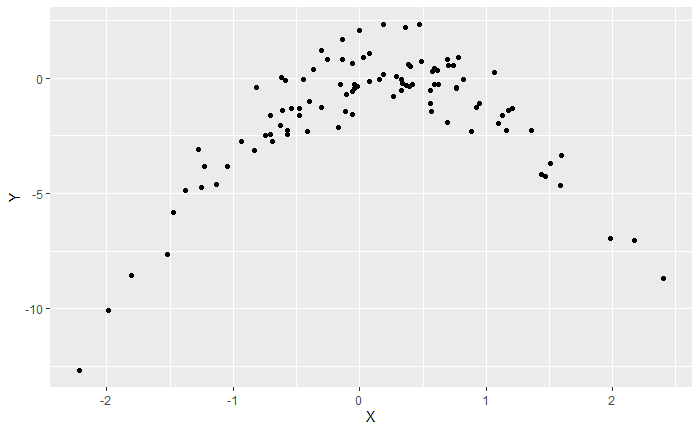

```r
library(ggplot2)
ggplot(dataset_1, aes(x = X, y = Y)) +
    geom_point()
```

`OBERVATION` *Relationship between X and Y:* The data show an uphill pattern as you move from left to right then about X = 0.5 then show a downhill pattern.This means there is no linear relationship between X and Y .

3. Use the dataset created in part(1) and predict Y using X using polynomial regression in R. The models that you need to build are shown below. You can adapt the code used in lecture 6.2.5 (the glm() and poly(X,i) commands) for building the regression models. After building each model, set a random seed (use the same seed for each model) and then compute the 5-fold cross validation error. Do not perform any backward step-wise selection on these linear models that you build.:
1. Y = β0 + β1X + e
2. Y = β0 + β1X + β2X2 + e
3. Y = β0 + β1X + β2X2 + β3X3 + e
4. Y = β0 + β1X + β2X2 + β3X3 + β4X4 + e Note that you may find it helpful to use the command data.frame() to create a single data set containing both X and Y

## i. Y = β0 + β1X + e

```r
library(boot)
set.seed(12)
model_full_1 <- glm(Y ~ X, data = dataset_1)
cv.glm(data = dataset_1, glmfit = model_full_1, K = 5)$delta[2]
```

```
[1] 7.805133
```

*OBVERSERVATION*: The 5-fold cross validation error of this model is 7.805133, which tells us on how our model performed.

## ii. Y = β0 + β1X + β2X2 + e

```r
library(boot)
set.seed(12)
model_full_2 <- glm(Y ~ X + X^2, data = dataset_1)
cv.glm(data = dataset_1, glmfit = model_full_2, K = 5)$delta[1]
```

```
[1] 7.963207
```

*OBVERSERVATION*: The 5-fold cross validation error of this model is 7.963207,which tells us on how our model performed.

## iii. Y = β0 + β1X + β2X2 + β3X3 + e

```r
library(boot)
set.seed(12)
model_full_3 <- glm(Y ~ X + X^2 + X^3 , data = dataset_1)
cv.glm(data = dataset_1, glmfit = model_full_3, K = 5)$delta[1]
```

```
[1] 7.963207
```

*OBVERSERVATION*: The 5-fold cross validation error of this model is 7.963207,which tells us on how our model performed.

## iv. Y = β0 + β1X + β2X2 + β3X3 + β4X4 + e

```r
library(boot)
set.seed(12)
model_full_4 <- glm(Y ~ X + X^2 + X^3 + X^4, data = dataset_1)
cv.glm(data = dataset_1, glmfit = model_full_4, K = 5)$delta[1]
```

```
[1] 7.963207
```

*OBVERSERVATION*: The 5-fold cross validation error of this model is 7.963207,which tells us on how our model performed.

4. Repeat 3 using another seed and report your results. Are your results the same as what you got in 3 ? Why ? *CODES* ## i. Y = β0 + β1X + e

```r
set.seed(121)
model_full_1 <- glm(Y ~ X, data = dataset_1)
cv.glm(data = dataset_1, glmfit = model_full_1, K = 5)$delta[2]
```

```
[1] 7.18355
```

*OBVERSERVATION*: The 5-fold cross validation error of this model is 7.18355, which tells us on how our model performed.

## statistical significance of the coefficient estimates from the model used to answer question 6

```r
summary(model_full_1)
```

```
Call:
glm(formula = Y ~ X, data = dataset_1)

Deviance Residuals:
    Min       1Q   Median       3Q      Max
-9.5161  -0.6800   0.6812   1.5491   3.8183

Coefficients:
            Estimate Std. Error t value Pr(>|t|)
(Intercept)  -1.6254     0.2619  -6.205 1.31e-08 ***
X             0.6925     0.2909   2.380   0.0192 *
---
Signif. codes:  0 ‘***’ 0.001 ‘**’ 0.01 ‘*’ 0.05 ‘.’ 0.1 ‘ ’ 1

(Dispersion parameter for gaussian family taken to be 6.760719)

    Null deviance: 700.85  on 99  degrees of freedom
Residual deviance: 662.55  on 98  degrees of freedom
AIC: 478.88

Number of Fisher Scoring iterations: 2
```

## ii. Y = β0 + β1X + β2X2 + e

```r
set.seed(121)
model_full_2 <- glm(Y ~ X + X^2, data = dataset_1)
cv.glm(data = dataset_1, glmfit = model_full_2, K = 5)$delta[1]
```

```
[1] 7.254846
```

*OBVERSERVATION*: The 5-fold cross validation error of this model is 7.254846,which tells us on how our model performed.

## statistical significance of the coefficient estimates from the model used to answer question 6

```r
summary(model_full_2)
```

```
Call:
glm(formula = Y ~ X + X^2, data = dataset_1)

Deviance Residuals:
    Min       1Q   Median       3Q      Max
-9.5161  -0.6800   0.6812   1.5491   3.8183

Coefficients:
            Estimate Std. Error t value Pr(>|t|)
(Intercept)  -1.6254     0.2619  -6.205 1.31e-08 ***
X             0.6925     0.2909   2.380   0.0192 *
---
Signif. codes:  0 ‘***’ 0.001 ‘**’ 0.01 ‘*’ 0.05 ‘.’ 0.1 ‘ ’ 1

(Dispersion parameter for gaussian family taken to be 6.760719)

    Null deviance: 700.85  on 99  degrees of freedom
Residual deviance: 662.55  on 98  degrees of freedom
AIC: 478.88

Number of Fisher Scoring iterations: 2
```

## iii. Y = β0 + β1X + β2X2 + β3X3 + e

```r
set.seed(121)
model_full_3 <- glm(Y ~ X + X^2 + X^3 , data = dataset_1)
cv.glm(data = dataset_1, glmfit = model_full_3, K = 5)$delta[1]
```

```
[1] 7.254846
```

*OBSERVATION*: The 5-fold cross validation error of this model is 7.254846, which tells us on how our model performed.

## statistical significance of the coefficient estimates from the model used to answer question 6

```r
summary(model_full_3)
```

```
Call:
glm(formula = Y ~ X + X^2 + X^3, data = dataset_1)

Deviance Residuals:
    Min       1Q   Median       3Q      Max
-9.5161  -0.6800   0.6812   1.5491   3.8183

Coefficients:
            Estimate Std. Error t value Pr(>|t|)
(Intercept)  -1.6254     0.2619  -6.205 1.31e-08 ***
X             0.6925     0.2909   2.380   0.0192 *
---
Signif. codes:  0 ‘***’ 0.001 ‘**’ 0.01 ‘*’ 0.05 ‘.’ 0.1 ‘ ’ 1

(Dispersion parameter for gaussian family taken to be 6.760719)

    Null deviance: 700.85  on 99  degrees of freedom
Residual deviance: 662.55  on 98  degrees of freedom
AIC: 478.88

Number of Fisher Scoring iterations: 2
```

## iv. Y = β0 + β1X + β2X2 + β3X3 + β4X4 + e

```r
set.seed(121)
model_full_4 <- glm(Y ~ X + X^2 + X^3 + X^4, data = dataset_1)
cv.glm(data = dataset_1, glmfit = model_full_4, K = 5)$delta[1]
```

```
[1] 7.254846
```

## statistical significance of the coefficient estimates from the model used to answer question 6

```r
summary(model_full_4)
```

```
Call:
glm(formula = Y ~ X + X^2 + X^3 + X^4, data = dataset_1)

Deviance Residuals:
    Min       1Q   Median       3Q      Max
-9.5161  -0.6800   0.6812   1.5491   3.8183

Coefficients:
            Estimate Std. Error t value Pr(>|t|)
(Intercept)  -1.6254     0.2619  -6.205 1.31e-08 ***
X             0.6925     0.2909   2.380   0.0192 *
---
Signif. codes:  0 ‘***’ 0.001 ‘**’ 0.01 ‘*’ 0.05 ‘.’ 0.1 ‘ ’ 1

(Dispersion parameter for gaussian family taken to be 6.760719)

    Null deviance: 700.85  on 99  degrees of freedom
Residual deviance: 662.55  on 98  degrees of freedom
AIC: 478.88

Number of Fisher Scoring iterations: 2
```

*ANSWER*: The 5-fold cross validation error are different since we used Set seed of different values.

**Question 2 (30 pts)** This question uses the Advertising dataset from week 5. 1. Code Linear Regression in R (use the tutorial file that was given last week for guidance) to build a model with sales as the dependent variable and TV and Radio as the predictor variables. Include the interaction term TV × Radio. 2. Compute the bootstrapped errors for the coefficients in this model. Compare these with the errors from part(1). Are they different? Explain why.